# Modern concepts and methods in Macroecology and Biogeography

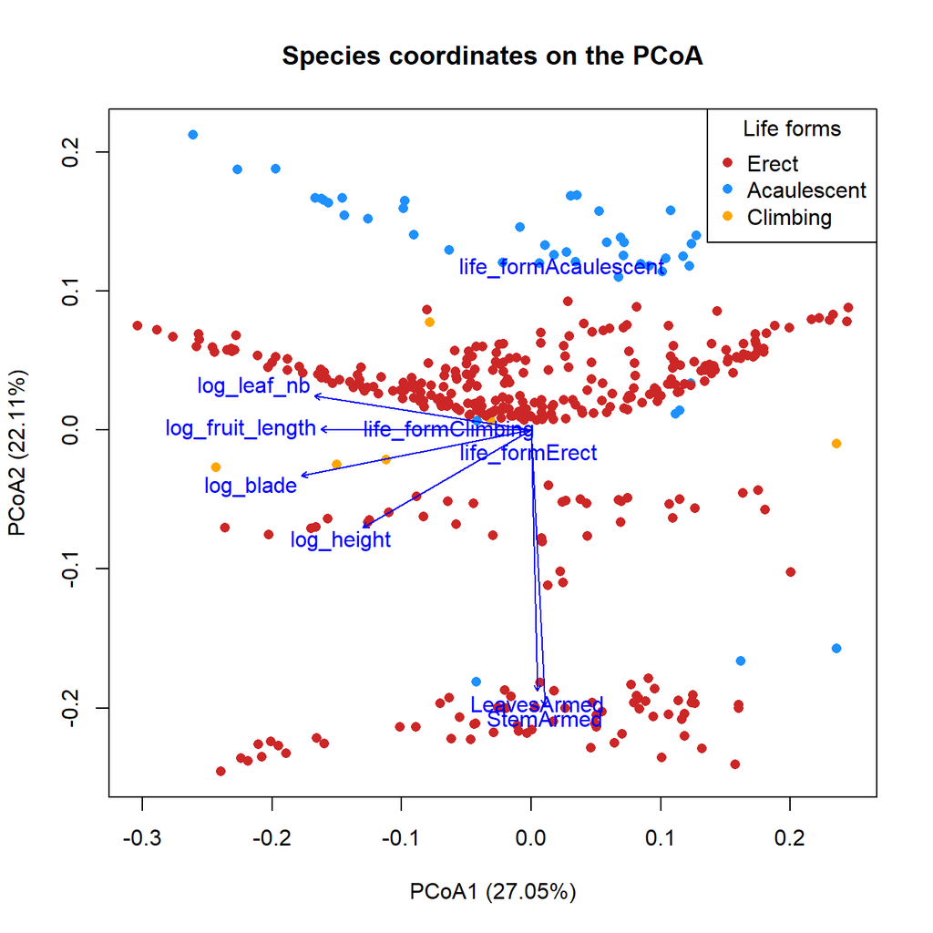

```r
# Check where are the different categories
# Create color column based on life form
sp_tra_complete$col <- ifelse(
  sp_tra_complete$life_form == "Erect", "firebrick3",
  ifelse(sp_tra_complete$life_form == "Acaulescent", "dodgerblue",
         "orange"))

plot(sp_tra_complete$A1_w, sp_tra_complete$A2_w, pch = 16,
     col = sp_tra_complete$col,
     main = "Species coordinates on the PCoA",
     xlab = paste0("PCoA1 (",
                   round((pcoa_palm_w$eig / sum(pcoa_palm_w$eig))*100,
                         2)[1],
                   "%)"),
     ylab = paste0("PCoA2 (",
                   round((pcoa_palm_w$eig / sum(pcoa_palm_w$eig))*100,
                         2)[2],
                   "%)"))
legend("topright", title = "Life forms",
       legend = c("Erect", "Acaulescent", "Climbing"),
       col = c("firebrick3", "dodgerblue", "orange"),
       pch = 16)
plot(ef, p.max = 0.1)
```

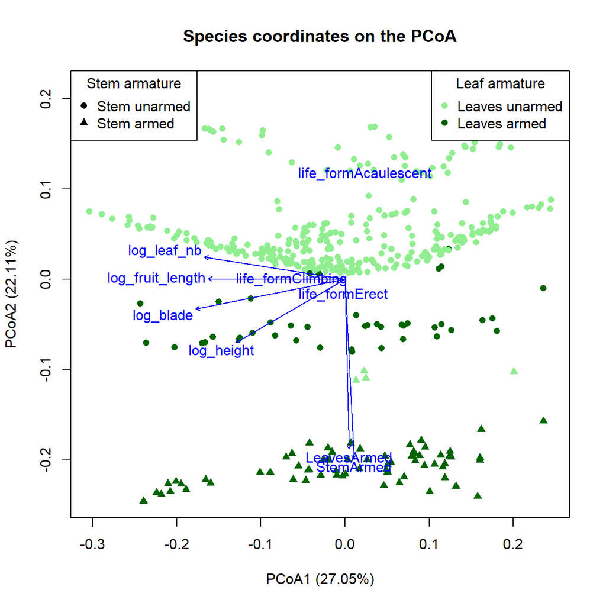

```r
# Create color and shape based on armature (leaves and stems)
sp_tra_complete$col <- ifelse(
  sp_tra_complete$LeavesArmed == 0, "lightgreen", "darkgreen")
sp_tra_complete$shape <- ifelse(
  sp_tra_complete$StemArmed == 0, 16, 17)

plot(sp_tra_complete$A1_w, sp_tra_complete$A2_w,
     col = sp_tra_complete$col,
     pch = sp_tra_complete$shape,
     # pch = c(16, 17)[as.numeric(sp_tra_complete$StemArmed)],
     main = "Species coordinates on the PCoA",
     xlab = paste0("PCoA1 (",
                   round((pcoa_palm_w$eig / sum(pcoa_palm_w$eig))*100,
                         2)[1],
                   "%)"),
     ylab = paste0("PCoA2 (",
                   round((pcoa_palm_w$eig / sum(pcoa_palm_w$eig))*100,
                         2)[2],
                   "%)"))
legend("topright", title = "Leaf armature",
       legend = c("Leaves unarmed", "Leaves armed"),
       col = c("lightgreen", "darkgreen"),
       pch = 16)
legend("topleft", title = "Stem armature",
       legend = c("Stem unarmed", "Stem armed"),
       pch = c(16, 17))
plot(ef, p.max = 0.1)
```

```r
# Plot of A1 and A2
# Map of trait coverage: MaxStemHeight_m
species_pcoa <- left_join(
  species[, c("grid_id", "species", "Long", "Lat")],
  sp_tra_complete[, c("sp", "A1_w", "A2_w")],
  by = c("species" = "sp"))
head(species_pcoa)
```

```
##   grid_id          species      Long   Lat A1_w A2_w
## 1   13735 Ammandra natalia -78.25066 -1.25   NA   NA
## 2   13736 Ammandra natalia -77.75066 -1.25   NA   NA
## 3   13737 Ammandra natalia -77.25066 -1.25   NA   NA
## 4   13738 Ammandra natalia -76.75066 -1.25   NA   NA
## 5   13910 Ammandra natalia -78.25066 -1.75   NA   NA
## 6   13911 Ammandra natalia -77.75066 -1.75   NA   NA
```

```r
# tapply function
grid_mean_pcoa1 <- tapply(species_pcoa$A1_w,
                          species_pcoa$grid_id,
                          function(x) mean(x, na.rm = TRUE))
grid_mean_pcoa1 <- data.frame(
  grid_id = names(grid_mean_pcoa1),
  mean_pcoa1 = as.numeric(grid_mean_pcoa1))

grid_mean_pcoa2 <- tapply(species_pcoa$A2_w,
                          species_pcoa$grid_id,
                          function(x) mean(x, na.rm = TRUE))
grid_mean_pcoa2 <- data.frame(
  grid_id = names(grid_mean_pcoa2),
  mean_pcoa2 = as.numeric(grid_mean_pcoa2))

# Plot
grid_mean_pcoa1$grid_id <- as.numeric(as.character(grid_mean_pcoa1$grid_id))
grid@data <- left_join(grid@data, grid_mean_pcoa1, by = "grid_id")
grid_mean_pcoa2$grid_id <- as.numeric(as.character(grid_mean_pcoa2$grid_id))
grid@data <- left_join(grid@data, grid_mean_pcoa2, by = "grid_id")

# Make a color ramp
col_func <- colorRampPalette(c("olivedrab1", "olivedrab4"))
col_func(10)
```

```
##  [1] "#C0FF3E" "#B6F23A" "#ACE537" "#A3D834" "#99CB31" "#8FBE2E" "#86B12B"
##  [8] "#7CA428" "#729725" "#698B22"
```

```r
my_col <- col_func(length(unique(grid@data$mean_pcoa1)))

col_func2 <- colorRampPalette(c("cadetblue1", "cadetblue4"))
col_func2(10)
```

```
##  [1] "#98F5FF" "#90E8F2" "#88DCE5" "#81D0D8" "#79C3CB" "#71B7BE" "#6AABB1"
##  [8] "#629EA4" "#5A9297" "#53868B"
```

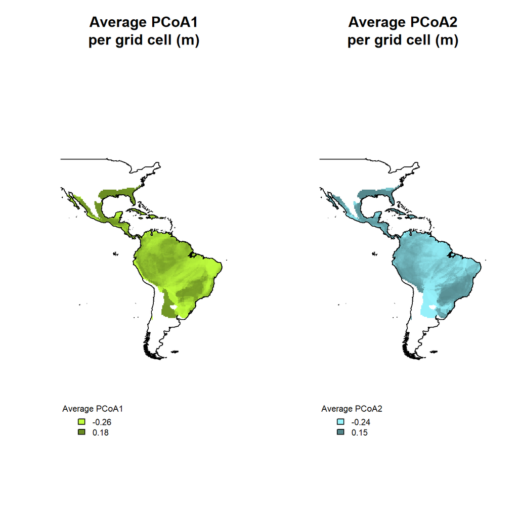

```r
my_col2 <- col_func2(length(unique(grid@data$mean_pcoa2)))

# Rank variable for color assignment
grid@data$order <- findInterval(grid@data$mean_pcoa1,
                                sort(grid@data$mean_pcoa1))
grid@data$order2 <- findInterval(grid@data$mean_pcoa2,
                                 sort(grid@data$mean_pcoa2))

# Plot of PCoA1 and PCoA2 distribution
par(mfrow = c(1, 2))
plot(grid, col = col_func(nrow(grid@data))[grid@data$order],
     border = NA,
     main = "Average PCoA1\nper grid cell (m)")
plot(americas, add = TRUE)

legend("bottomleft", # position
       legend = round(range(grid@data$mean_pcoa1, na.rm = TRUE), 2),
       title = "Average PCoA1",
       fill = col_func(2),
       cex = 0.7,
       bty = "n") # no box around it

plot(grid, col = col_func2(nrow(grid@data))[grid@data$order2],
     border = NA,
     main = "Average PCoA2\nper grid cell (m)")
plot(americas, add = TRUE)

legend("bottomleft", # position
       legend = round(range(grid@data$mean_pcoa2, na.rm = TRUE), 2),
       title = "Average PCoA2",
       fill = col_func2(2),
       cex = 0.7,
       bty = "n") # no box around it
```

# 4. Functional diversity

We here just focus on functional richness which is the volume of functional space occupied by a community convex hull that encompasses all points.

Mapping FRich on each grid.

## 4.1. Frich per grid cell

FRich for one cell

```r
# One grid cell only
tmp <- species_pcoa[which(species_pcoa$grid_id == 1832), ]

tmp_fd <- dbFD(x = tmp[, c("A1_w", "A2_w")], calc.FGR = FALSE,
               calc.CWM = FALSE, calc.FDiv = FALSE)
```

```
## FRic: No dimensionality reduction was required. The 2 PCoA axes were kept as 'traits'.
```

```r
tmp_fd$FRic
```

```
## Community1
##   1.314154
```

```r
# For all grid IDs
sp_frich <- species_pcoa[complete.cases(species_pcoa$A1_w), ]

grid_frich <- c()
for(i in 5230:length(unique(sp_frich$grid_id))){
  tmp <- sp_frich[which(sp_frich$grid_id == unique(sp_frich$grid_id)[i]), ]

  if(nrow(tmp) > 2){ # at least three species for a volume
  # FD indices
  tmp_fd <- dbFD(x = tmp[, c("A1_w", "A2_w")], calc.FGR = FALSE,
                 calc.CWM = FALSE, calc.FDiv = FALSE)

  # Binding the results
  tmp <- data.frame(grid_id = unique(sp_frich$grid_id)[i],
                    nb_sp = nrow(tmp),
                    frich = tmp_fd$FRic)
  rownames(tmp) <- NULL
  } else{
    tmp <- data.frame(grid_id = unique(sp_frich$grid_id)[i],
                      nb_sp = nrow(tmp),
                      frich = NA)
  }
  grid_frich <- rbind(grid_frich, tmp)
  print(i)
}
# saveRDS(grid_frich, "data/Frich_grid.rds")
```

```r
# Import results
grid_frich <- readRDS("data/Frich_grid.rds")
```

Map results

```r
# Plot
grid@data <- left_join(grid@data, grid_frich, by = "grid_id")

# Make a color ramp
col_func <- colorRampPalette(c("steelblue1", "steelblue4"))
col_func(10)
```

```
##  [1] "#63B8FF" "#5EAEF2" "#59A5E5" "#549CD8" "#4F92CB" "#4989BE" "#4580B1"
##  [8] "#4076A4" "#3B6D97" "#36648B"
```

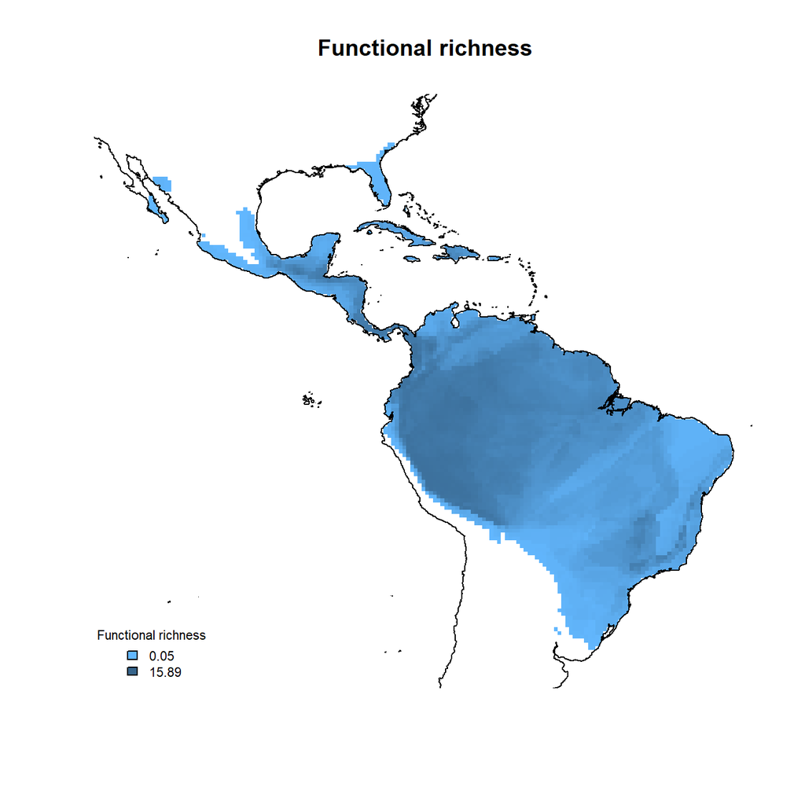

```r
my_col <- col_func(length(unique(grid@data$frich)))

# Rank variable for color assignment
grid@data$order <- findInterval(grid@data$frich,
                                sort(grid@data$frich))

# Plot of height distribution
plot(grid, col = col_func(nrow(grid@data))[grid@data$order],
     border = NA,
     main = "Functional richness")
plot(americas, add = TRUE)

legend("bottomleft", # position
       legend = round(range(grid@data$frich, na.rm = TRUE), 2),
       title = "Functional richness",
       fill = col_func(2),
       cex = 0.7,
       bty = "n") # no box around it
```

## 4.2. Link with SR

Plot of the bias

```r
sr_frich <- lm(frich ~ nb_sp, data = grid_frich)
summary(sr_frich)
```

```
##
## Call:
## lm(formula = frich ~ nb_sp, data = grid_frich)
##
## Residuals:
##     Min      1Q  Median      3Q     Max
## -4.6357 -0.9347  0.1637  0.9137  4.4630
##
## Coefficients:
##             Estimate Std. Error t value Pr(>|t|)
## (Intercept) 3.320140   0.036465   91.05   <2e-16 ***
## nb_sp       0.194064   0.001394  139.22   <2e-16 ***
## ---
## Signif. codes:  0 '***' 0.001 '**' 0.01 '*' 0.05 '.' 0.1 ' ' 1
##
## Residual standard error: 1.46 on 5559 degrees of freedom
##   (1000 observations deleted due to missingness)
## Multiple R-squared:  0.7771, Adjusted R-squared:  0.7771
## F-statistic: 1.938e+04 on 1 and 5559 DF,  p-value: < 2.2e-16
```

```r
sr_frich2 <- lm(frich ~ nb_sp + I(nb_sp^2), data = grid_frich)
summary(sr_frich2)
```

```
##
## Call:
## lm(formula = frich ~ nb_sp + I(nb_sp^2), data = grid_frich)
##
## Residuals:
##     Min      1Q  Median      3Q     Max
## -3.2091 -0.8130 -0.0876  0.8019  4.5842
##
## Coefficients:
##               Estimate Std. Error t value Pr(>|t|)
## (Intercept)  1.387e+00  4.910e-02   28.24   <2e-16 ***
## nb_sp        4.178e-01  4.620e-03   90.43   <2e-16 ***
## I(nb_sp^2)  -4.391e-03  8.777e-05  -50.03   <2e-16 ***
## ---
## Signif. codes:  0 '***' 0.001 '**' 0.01 '*' 0.05 '.' 0.1 ' ' 1
##
## Residual standard error: 1.212 on 5558 degrees of freedom
##   (1000 observations deleted due to missingness)
## Multiple R-squared:  0.8463, Adjusted R-squared:  0.8463
## F-statistic: 1.53e+04 on 2 and 5558 DF,  p-value: < 2.2e-16
```

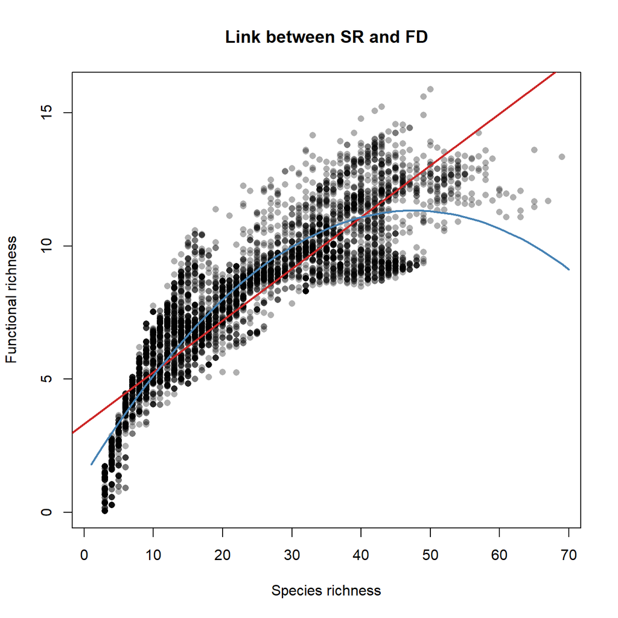

```r
plot(grid_frich$nb_sp, grid_frich$frich, pch = 16,
     col = "#00000050", main = "Link between SR and FD",
     xlab = "Species richness", ylab = "Functional richness")
abline(sr_frich, col = "firebrick3", lwd = 2)
points(predict(sr_frich2, data.frame(nb_sp = 1:70)),
       col = "steelblue", lwd = 2, type = "l")
```

# References

[Kissling, W. D., Balslev, H., Baker, W. J., Dransfield, J., Göldel, B., Lim, J. Y., Onstein, R. E., & Svenning, J.-C. (2019). PalmTraits 1.0, a species-level functional trait database of palms worldwide. Scientific Data, 6(1), 1–13.](https://www.nature.com/articles/s41597-019-0189-0)